# Homework 11

Solutions will be available after Monday, November 9, 2026.

## Question 1: Implementing K-means

K-means is a relatively simple algorithm that we can write ourselves. For Questions 1 and 2, do not use an existing function that performs K-means directly.

Generate 10 observations with two independent standard normal coordinates. Set a random seed and report it. Randomly assign the observations to $K=2$ clusters, making sure neither cluster is empty. Let $C(i)$ denote the cluster assigned to observation $x_i$, and let $m_k$ denote the mean of cluster $k$.

1. Perform one iteration: calculate the cluster means, then assign each observation to its closest mean using Euclidean distance. Report the means and updated assignments, and plot the observations colored by their updated assignments.

```r
random_assignment <- function(n, K) {
  stopifnot(K >= 1, K <= n)
  groups <- integer(n)
  groups[sample.int(n)] <- c(seq_len(K), sample.int(K, n - K, replace = TRUE))
  groups
}

update_centers <- function(x, groups, centers) {
  for (k in seq_len(nrow(centers))) {
    members <- groups == k
    if (any(members)) {
      centers[k, ] <- colMeans(x[members, , drop = FALSE])
    }
  }
  centers
}

assign_nearest <- function(x, centers) {
  squared_distances <- matrix(0, nrow(x), nrow(centers))
  for (k in seq_len(nrow(centers))) {
    differences <- sweep(x, 2, centers[k, ], FUN = "-")
    squared_distances[, k] <- rowSums(differences^2)
  }
  max.col(-squared_distances, ties.method = "first")
}

set.seed(123)
x <- matrix(rnorm(20), nrow = 10, ncol = 2,
            dimnames = list(NULL, c("x1", "x2")))
start_1 <- random_assignment(nrow(x), 2)
first_centers <- update_centers(
  x, start_1, matrix(NA_real_, 2, ncol(x), dimnames = list(NULL, colnames(x)))
)
after_one <- assign_nearest(x, first_centers)

show_table <- function(x, caption) {
  cat(knitr::kable(x, digits = 4, caption = caption, row.names = FALSE),
      sep = "\n")
  cat("\n\n")
}

show_table(data.frame(Cluster = 1:2, first_centers),
           "Initial centers used for the first reassignment")
```

```
Table: Initial centers used for the first reassignment

| Cluster|      x1|     x2|
|-------:|-------:|------:|
|       1| -0.0542| 0.2382|
|       2|  0.2679| 0.1642|
```

```r
show_table(data.frame(Observation = 1:10, x, Initial = start_1,
                      Updated = after_one),
           "Assignments before and after one iteration")
```

```
Table: Assignments before and after one iteration

| Observation|      x1|      x2| Initial| Updated|
|-----------:|-------:|-------:|-------:|-------:|
|           1| -0.5605|  1.2241|       1|       1|
|           2| -0.2302|  0.3598|       1|       1|
|           3|  1.5587|  0.4008|       2|       2|
|           4|  0.0705|  0.1107|       2|       1|
|           5|  0.1293| -0.5558|       2|       2|
|           6|  1.7151|  1.7869|       1|       2|
|           7|  0.4609|  0.4979|       1|       2|
|           8| -1.2651| -1.9666|       1|       1|
|           9| -0.6869|  0.7014|       2|       1|
|          10| -0.4457| -0.4728|       1|       1|
```

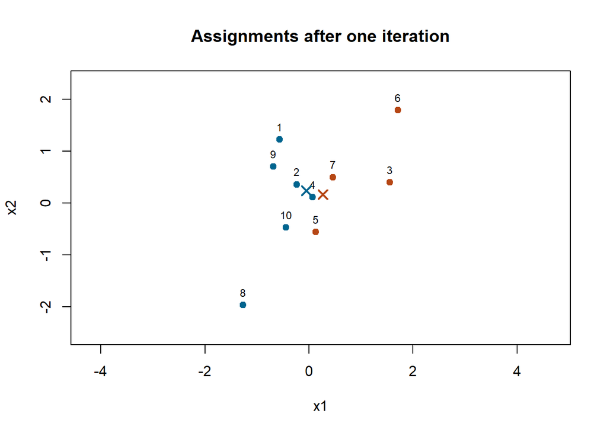

```r
plot_groups <- function(x, groups, centers, title) {
  colors <- c("#00658F", "#B64715")
  plot(x, col = colors[groups], pch = 19, asp = 1,
       xlab = "x1", ylab = "x2", main = title,
       xlim = extendrange(x[, 1], f = .15),
       ylim = extendrange(x[, 2], f = .15))
  text(x, labels = seq_len(nrow(x)), pos = 3, cex = .74)
  points(centers, col = colors[seq_len(nrow(centers))], pch = 4,
         lwd = 2, cex = 1.4)
}

plot_groups(x, after_one, first_centers, "Assignments after one iteration")
```

2. Write a function that repeats these two steps until the assignments stop changing or a specified maximum number of iterations is reached. Your function should work for a data matrix with any number of variables and a chosen number of clusters $K$. Start from a nonempty assignment to each cluster; if a cluster becomes empty during iteration, keep its previous mean. Recalculate the cluster means from the final assignments before returning them. Return the final assignments, cluster means, and within-cluster sum of squares,

   $$\sum_{k=1}^K\sum_{i:\,C(i)=k}\lVert x_i-m_k\rVert^2.$$

```r
my_kmeans <- function(x, K, max_iter = 100L, init = NULL) {
  stopifnot(is.matrix(x), is.numeric(x), all(is.finite(x)),
            nrow(x) >= 1L, ncol(x) >= 1L,
            length(K) == 1L, is.finite(K), K == floor(K),
            K >= 1L, K <= nrow(x),
            length(max_iter) == 1L, is.finite(max_iter),
            max_iter >= 1L, max_iter == floor(max_iter))
  if (is.null(init)) init <- random_assignment(nrow(x), K)
  stopifnot(length(init) == nrow(x), all(init %in% seq_len(K)),
            all(seq_len(K) %in% init))

  groups <- as.integer(init)
  centers <- matrix(NA_real_, nrow = K, ncol = ncol(x),
                    dimnames = list(NULL, colnames(x)))
  converged <- FALSE
  for (iteration in seq_len(max_iter)) {
    centers <- update_centers(x, groups, centers)
    updated <- assign_nearest(x, centers)
    if (identical(groups, updated)) {
      converged <- TRUE
      break
    }
    groups <- updated
  }

  centers <- update_centers(x, groups, centers)
  wcss <- sum((x - centers[groups, , drop = FALSE])^2)
  list(cluster = groups, centers = centers, wcss = wcss,
       iterations = iteration, converged = converged)
}
```

```r
set.seed(321)
start_2 <- random_assignment(nrow(x), 2)
stopifnot(!identical(start_1, start_2))
fit_1 <- my_kmeans(x, 2, init = start_1)
fit_2 <- my_kmeans(x, 2, init = start_2)

show_table(data.frame(Observation = 1:10, Start_1 = start_1, Start_2 = start_2,
                      Final_1 = fit_1$cluster, Final_2 = fit_2$cluster),
           "Initial and final assignments")
```

```
Table: Initial and final assignments

| Observation| Start_1| Start_2| Final_1| Final_2|
|-----------:|-------:|-------:|-------:|-------:|
|           1|       1|       1|       1|       1|
|           2|       1|       1|       1|       1|
|           3|       2|       2|       2|       2|
|           4|       2|       2|       1|       1|
|           5|       2|       2|       1|       1|
|           6|       1|       2|       2|       2|
|           7|       1|       2|       2|       2|
|           8|       1|       2|       1|       1|
|           9|       2|       1|       1|       1|
|          10|       1|       1|       1|       1|
```

```r
show_table(rbind(data.frame(Run = 1, Cluster = 1:2, fit_1$centers),
                 data.frame(Run = 2, Cluster = 1:2, fit_2$centers)),
           "Final centers from the two runs")
```

```
Table: Final centers from the two runs

| Run| Cluster|      x1|      x2|
|---:|-------:|-------:|-------:|
|   1|       1| -0.4269| -0.0856|
|   1|       2|  1.2449|  0.8952|
|   2|       1| -0.4269| -0.0856|
|   2|       2|  1.2449|  0.8952|
```

```r
show_table(data.frame(Run = 1:2, WCSS = c(fit_1$wcss, fit_2$wcss),
                      Iterations = c(fit_1$iterations, fit_2$iterations),
                      Converged = c(fit_1$converged, fit_2$converged)),
           "Objective values and convergence")
```

```
Table: Objective values and convergence

| Run|   WCSS| Iterations|Converged |
|---:|------:|----------:|:---------|
|   1| 9.9962|          3|TRUE      |
|   2| 9.9962|          3|TRUE      |
```

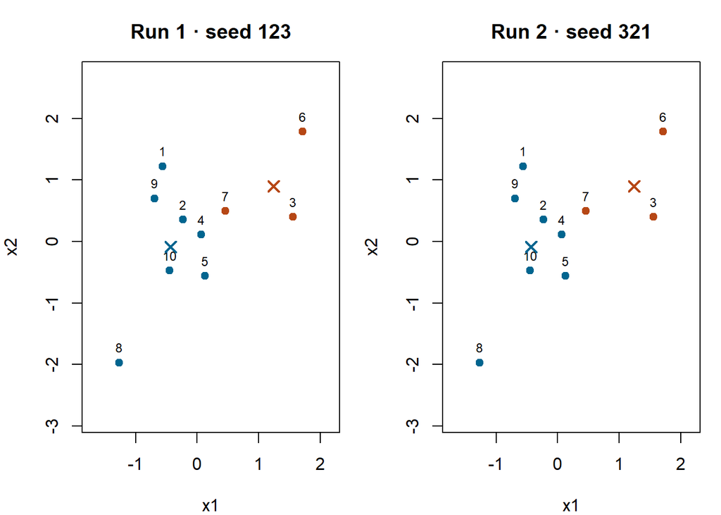

```r
old_par <- par(mfrow = c(1, 2), mar = c(4, 4, 3, 1))
plot_groups(x, fit_1$cluster, fit_1$centers, "Run 1 · seed 123")
plot_groups(x, fit_2$cluster, fit_2$centers, "Run 2 · seed 321")
```

```r
par(old_par)

same_grouping <- identical(
  outer(fit_1$cluster, fit_1$cluster, "=="),
  outer(fit_2$cluster, fit_2$cluster, "==")
)
same_objective <- isTRUE(all.equal(fit_1$wcss, fit_2$wcss))
```

## Question 2: Image color compression

Pick your favorite color image and use your K-means function from Question 1 to cluster its pixels. For computational efficiency, resize the image to no more than $200\times200$ pixels and use its three RGB color channels.

1. Plot the original image and report its dimensions. Transform it into a data matrix with one observation per pixel and three variables: red, green, and blue. Report the dimensions of this matrix.

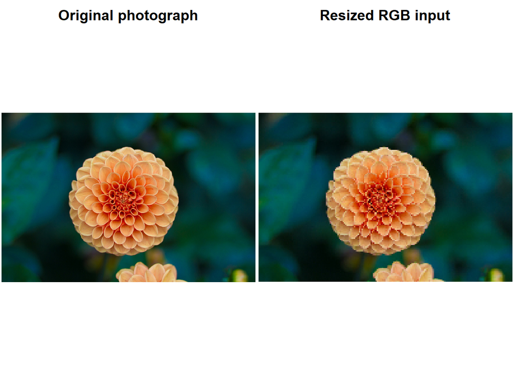

```r
original <- jpeg::readJPEG("flower.jpg")
stopifnot(length(dim(original)) == 3, dim(original)[3] == 3)
original_size <- dim(original)[1:2]
target_size <- pmax(1L, round(original_size * min(1, 200 / max(original_size))))
rows <- round(seq(1, original_size[1], length.out = target_size[1]))
cols <- round(seq(1, original_size[2], length.out = target_size[2]))
image_rgb <- original[rows, cols, , drop = FALSE]

height <- dim(image_rgb)[1]
width <- dim(image_rgb)[2]
pixels <- matrix(image_rgb, ncol = 3,
                 dimnames = list(NULL, c("Red", "Green", "Blue")))

plot_image <- function(a, title) {
  plot.new()
  plot.window(xlim = c(0, dim(a)[2]), ylim = c(0, dim(a)[1]),
              asp = 1, xaxs = "i", yaxs = "i")
  rasterImage(as.raster(a), 0, 0, dim(a)[2], dim(a)[1],
              interpolate = FALSE)
  title(main = title)
}

old_par <- par(mfrow = c(1, 2), mar = c(.1, .1, 2, .1))
plot_image(original, "Original photograph")
plot_image(image_rgb, "Resized RGB input")
```

```r
par(old_par)
```

2. For $K=2,3,5,10$, apply your function to the pixel data. Report the cluster means and within-cluster sum of squares for each $K$. Reconstruct and plot each compressed image by replacing every pixel with its assigned cluster mean. Use the same RGB scale for all fits.

```r
ks <- c(2L, 3L, 5L, 10L)
set.seed(123)
fits <- lapply(ks, function(k) {
  runs <- replicate(5, my_kmeans(pixels, k, max_iter = 200L), simplify = FALSE)
  runs[[which.min(vapply(runs, function(fit) fit$wcss, numeric(1)))]]
})

wcss <- vapply(fits, function(fit) fit$wcss, numeric(1))
show_table(data.frame(K = ks, WCSS = wcss,
                      Converged = vapply(fits, function(fit) fit$converged, logical(1))),
           "Pixel WCSS for the selected fit at each K")
```

```
Table: Pixel WCSS for the selected fit at each K

|  K|     WCSS|Converged |
|--:|--------:|:---------|
|  2| 877.2002|TRUE      |
|  3| 584.4830|TRUE      |
|  5| 326.3657|TRUE      |
| 10| 137.5070|TRUE      |
```

```r
palettes <- Map(function(k, fit) {
  data.frame(K = k, Cluster = seq_len(k), fit$centers)
}, ks, fits)
show_table(do.call(rbind, palettes), "Cluster centers on the common RGB scale")
```

```
Table: Cluster centers on the common RGB scale

|  K| Cluster|    Red|  Green|   Blue|
|--:|-------:|------:|------:|------:|
|  2|       1| 0.8246| 0.5317| 0.3123|
|  2|       2| 0.0247| 0.2122| 0.1954|
|  3|       1| 0.0203| 0.2127| 0.1967|
|  3|       2| 0.7141| 0.2959| 0.1093|
|  3|       3| 0.8621| 0.6292| 0.3998|
|  5|       1| 0.3555| 0.2601| 0.1215|
|  5|       2| 0.0061| 0.2800| 0.2859|
|  5|       3| 0.7638| 0.3086| 0.1104|
|  5|       4| 0.0251| 0.1505| 0.1189|
|  5|       5| 0.8622| 0.6321| 0.4034|
| 10|       1| 0.0246| 0.1822| 0.1487|
| 10|       2| 0.8544| 0.5771| 0.3344|
| 10|       3| 0.8291| 0.3558| 0.1065|
| 10|       4| 0.6200| 0.4470| 0.2417|
| 10|       5| 0.0209| 0.0939| 0.0661|
| 10|       6| 0.6695| 0.0955| 0.0196|
| 10|       7| 0.0076| 0.2442| 0.2375|
| 10|       8| 0.8892| 0.7114| 0.4990|
| 10|       9| 0.0027| 0.3199| 0.3418|
| 10|      10| 0.2286| 0.2478| 0.1202|
```

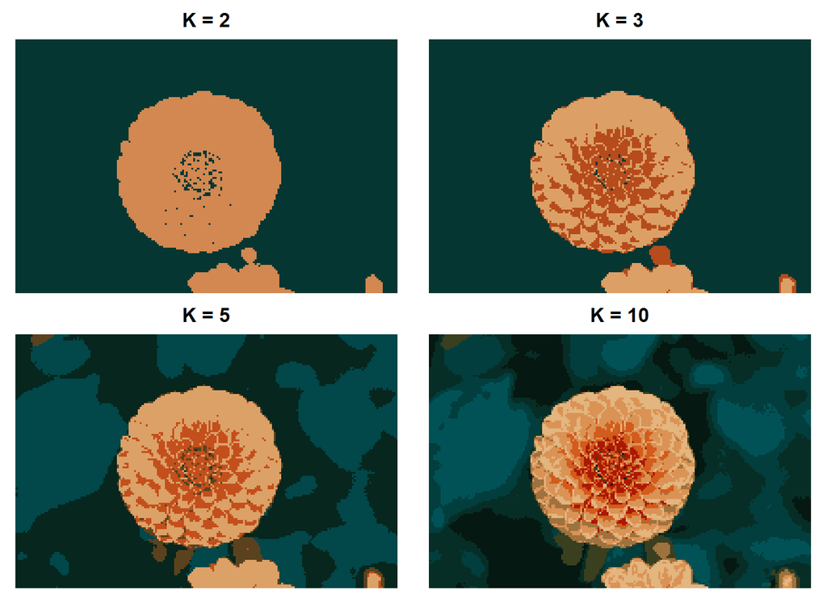

```r
old_par <- par(mfrow = c(2, 2), mar = c(.1, .1, 2, .1))
for (i in seq_along(ks)) {
  fit <- fits[[i]]
  reconstructed <- array(fit$centers[fit$cluster, , drop = FALSE],
                         dim = c(height, width, 3L))
  plot_image(reconstructed, paste("K =", ks[i]))
}
```

```r
par(old_par)
```

3. Which value of $K$ would you choose for this image? Briefly justify your choice using the reconstructed images and the within-cluster sums of squares.

## Question 3: Hierarchical clustering of cars

The file `data/mtcars.csv` contains 11 numerical variables for 32 cars, including fuel economy, horsepower, and weight. The `car` column gives the model names; use it to label observations, not as a clustering variable. You may use existing hierarchical clustering functions for this question.

1. Standardize each numerical variable to have mean 0 and standard deviation 1. Using Euclidean distance, perform hierarchical clustering with single, complete, and average linkage. Plot the three dendrograms with the car names and compare the results.

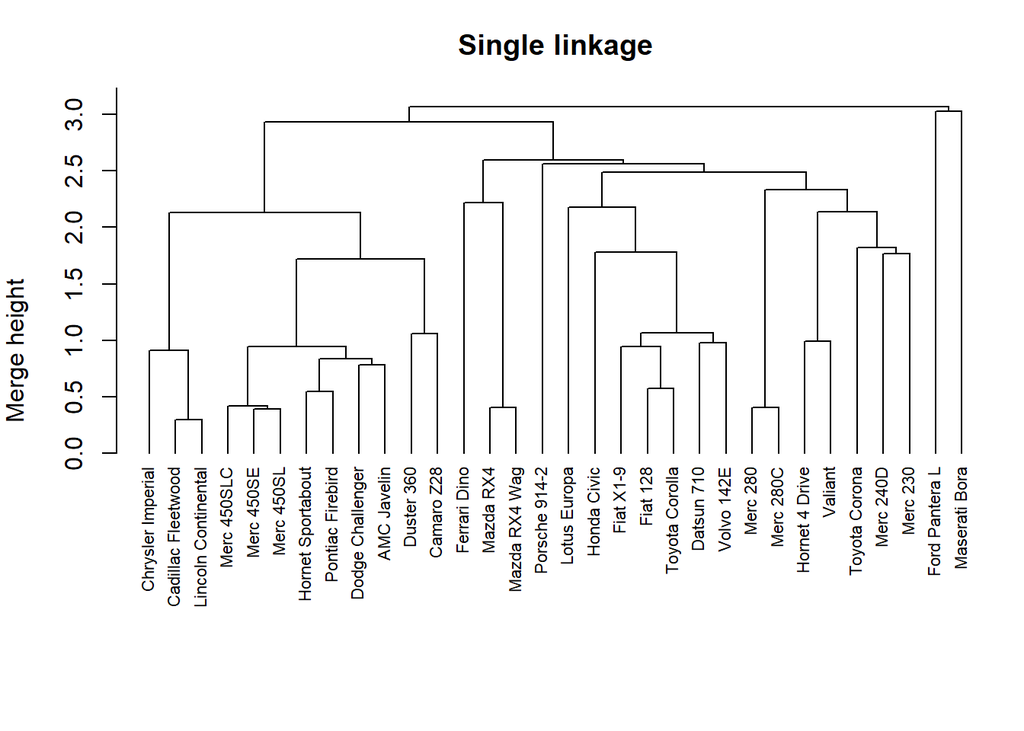

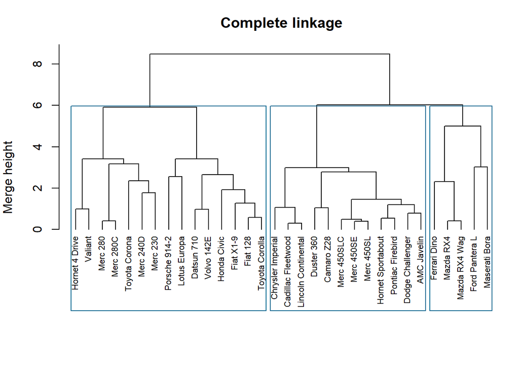

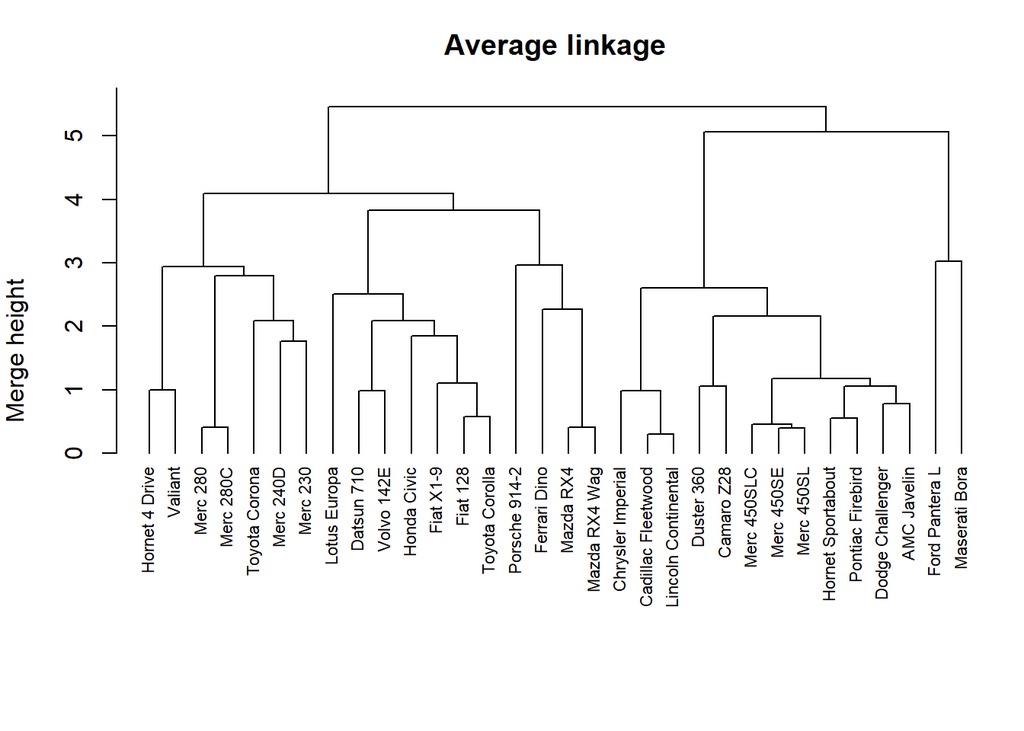

```r
cars <- read.csv("mtcars.csv", check.names = FALSE)
car_names <- cars$car
car_values <- cars[, names(cars) != "car", drop = FALSE]
rownames(car_values) <- car_names

car_z <- scale(car_values)
car_dist <- dist(car_z, method = "euclidean")
methods <- c("single", "complete", "average")
trees <- setNames(lapply(methods, function(method) {
  hclust(car_dist, method = method)
}), methods)

#| fig-width: 10.5
#| fig-height: 4.2

old_par <- par(mfrow = c(1, 1), mar = c(4, 4, 3, 1))

for (method in methods) {
  plot(trees[[method]], labels = car_names, cex = 0.7, hang = -1,
       main = paste(tools::toTitleCase(method), "linkage"),
       xlab = "", sub = "", ylab = "Merge height")

  if (method == "complete") {
    rect.hclust(trees[[method]], k = 3, border = "#00658F")
  }
}
```

```r
par(old_par)
```

Single linkage merges clusters using their closest pair of cars. It shows chaining here, with a three-cluster cut yielding sizes 30, 1, and 1. Complete linkage uses the farthest pair, and its three-cluster cut gives sizes 5, 15, and 12. Average linkage uses the mean distance across pairs, and its three-cluster cut gives sizes 18, 12, and 2. The partitions show how changing the linkage rule changes the grouping even when the data and distance matrix are the same.

2. Choose one linkage method and a number of clusters that you consider reasonable. Report the cluster memberships and a table of cluster means on the original variable scales. Describe the main characteristics of the groups and explain your choice using the dendrogram and table. Briefly explain why standardizing the variables matters for this analysis.

```r
groups <- cutree(trees$complete, k = 3)
members <- split(names(groups), groups)
show_table(data.frame(Cluster = names(members), Size = lengths(members),
                      Cars = vapply(members, paste, collapse = ", ",
                                    FUN.VALUE = character(1))),
           "Membership of the three complete-linkage clusters")
```

Membership of the three complete-linkage clusters

| Cluster | Size | Cars |
| --- | --- | --- |
| 1 | 5 | Mazda RX4, Mazda RX4 Wag, Ford Pantera L, Ferrari Dino, Maserati Bora |
| 2 | 15 | Datsun 710, Hornet 4 Drive, Valiant, Merc 240D, Merc 230, Merc 280, Merc 280C, Fiat 128, Honda Civic, Toyota Corolla, Toyota Corona, Fiat X1-9, Porsche 914-2, Lotus Europa, Volvo 142E |
| 3 | 12 | Hornet Sportabout, Duster 360, Merc 450SE, Merc 450SL, Merc 450SLC, Cadillac Fleetwood, Lincoln Continental, Chrysler Imperial, Dodge Challenger, AMC Javelin, Camaro Z28, Pontiac Firebird |

```r
profiles <- aggregate(car_values, by = list(Cluster = unname(groups)), FUN = mean)
profiles$Size <- as.integer(table(groups))
profiles <- profiles[, c("Cluster", "Size", names(car_values))]
show_table(profiles, "Cluster means on the original variable scales")
```

Cluster means on the original variable scales

| Cluster | Size | mpg | cyl | disp | hp | drat | wt | qsec | vs | am | gear | carb |
| --- | --- | --- | --- | --- | --- | --- | --- | --- | --- | --- | --- | --- |
| 1 | 5 | 18.5000 | 6.8000 | 223.4000 | 198.8000 | 3.8360 | 3.0010 | 15.6160 | 0.0000 | 1.0000 | 4.6000 | 5.2000 |
| 2 | 15 | 24.6533 | 4.5333 | 131.6467 | 91.3333 | 3.8973 | 2.5799 | 19.1580 | 0.9333 | 0.5333 | 3.9333 | 1.8000 |
| 3 | 12 | 15.0500 | 8.0000 | 357.6167 | 194.1667 | 3.1208 | 4.1041 | 17.1425 | 0.0000 | 0.0000 | 3.0000 | 3.0833 |

```r
three_cluster_interval <- tail(trees$complete$height, 3)[1:2]
```

- Cluster 1 (5 cars) consists entirely of manuals. It has the highest mean horsepower (198.8 hp) and the shortest mean quarter-mile time (15.62 s).
- Cluster 2 (15 cars) is the lightest group on average (2.58 thousand lb) and has the highest mean fuel economy (24.65 mpg) and the lowest mean horsepower (91.3 hp).
- Cluster 3 (12 cars) consists entirely of eight-cylinder automatics. It has the highest mean weight (4.10 thousand lb) and the lowest mean fuel economy (15.05 mpg).

Standardization matters because raw Euclidean distances would give variables with large numerical spreads, such as displacement and horsepower, more influence than variables measured on smaller scales. After standardization, a one-standard-deviation difference has the same squared contribution in each variable. For binary variables such as `am` and `vs`, the original-scale cluster means are the proportions coded 1.